# Exploratory Data Analysis

```python
import numpy as np
from math import ceil
import pandas as pd
%matplotlib inline
import matplotlib.pyplot as plt
```

## Variables

### Constants

```python
COLORS_FORECAST = ['navy', 'green']
COLORS_MEASUREMENT = ['navy', 'green', 'purple']
```

### Other variables

```python
columns_forecast = []
columns_measurement = []
removed_records_1 = 0
removed_records_2 = 0
```

## Functions

```python
def plot_histograms(data, title_1, title_2, color):
    """
    Create histograms
    =================

    Parameters:
    -----------
    data : pandas dataframe or series
           Data for prediction

    title_1 : string
              Title of the first histogram.

    title_2 : string
              Title of the first histogram.

    color : string
            Color for histogram.

    Returns:
    --------
    None

    Output:
    -------
    2 normal histograms. Difference between histograms is the number of bins.
    """
    len_data = len(data)

    min_value = int(data.min())
    max_value = int(ceil(data.max()))

    bins_1 = max_value - min_value
    if len_data >= 1000:
        bins_2 = 1000
    else:
        bins_2 = len_data

    f = plt.figure()
    f.set_figwidth(20)

    h1 = f.add_subplot(1, 2, 1)
    h1.set_title('{}'.format(title_1))

    for element in ([h1.title, h1.xaxis.label, h1.yaxis.label] + h1.get_xticklabels() + h1.get_yticklabels()):
        element.set_fontsize(20)

    h1.axes.set_xlim(xmin= min_value, xmax=max_value)
    plt.hist(data, bins=bins_1, color=color)

    h2 = f.add_subplot(1, 2, 2)
    h2.set_title('{}'.format(title_2))

    for element in ([h2.title, h2.xaxis.label, h2.yaxis.label] + h2.get_xticklabels() + h2.get_yticklabels()):
        element.set_fontsize(20)

    h2.axes.set_xlim(xmin= min_value, xmax=max_value)
    plt.hist(data, bins=bins_2, color=color)

    plt.show()



def plot_histograms_cumulative(data, title_1, title_2, color):
    """
    Create cumulative histograms
    ============================

    Parameters:
    -----------
    data : pandas dataframe or series
           Data for prediction

    title_1 : string
              Title of the first histogram.

    title_2 : string
              Title of the first histogram.

    color : string
            Color for histogram.

    Returns:
    --------
    None

    Output:
    -------
    2 cumulative histograms. Difference between histograms is the number of bins.
    """

    len_data = len(data)

    min_value = int(data.min())
    max_value = int(ceil(data.max()))

    bins_1 = max_value - min_value
    if len_data >= 1000:
        bins_2 = 1000
    else:
        bins_2 = len_data

    f = plt.figure()
    f.set_figwidth(20)

    h1 = f.add_subplot(1, 2, 1)
    h1.set_title('{}'.format(title_1))

    for element in ([h1.title, h1.xaxis.label, h1.yaxis.label]
                    + h1.get_xticklabels()
                    + h1.get_yticklabels()):
        element.set_fontsize(20)

    h1.axes.set_xlim(xmin= min_value, xmax=max_value)
    plt.hist(data, bins=bins_1, color=color, cumulative=True)

    h2 = f.add_subplot(1, 2, 2)
    h2.set_title('{}'.format(title_2))

    for element in ([h2.title, h2.xaxis.label, h2.yaxis.label]
                    + h2.get_xticklabels()
                    + h2.get_yticklabels()):
        element.set_fontsize(20)

    h2.axes.set_xlim(xmin= min_value, xmax=max_value)
    plt.hist(data, bins=bins_2, color=color, cumulative=True)

    plt.show()
```

## Datasets overview

This section is about opening the different datasets and getting an overview about their structure.

### Forecasts

```python
dataset1_forecast = pd.read_csv('./data/Dateset#1/Dataset1_forecast.csv', delimiter =',')
dataset1_forecast.info()
```

```
<class 'pandas.core.frame.DataFrame'>
RangeIndex: 7388 entries, 0 to 7387
Data columns (total 3 columns):
 #   Column            Non-Null Count  Dtype
---  ------            --------------  -----
 0   Time              7388 non-null   object
 1   windSpeed (m/s)   7388 non-null   float64
 2   windDic (degree)  7388 non-null   float64
dtypes: float64(2), object(1)
memory usage: 173.3+ KB
```

```python
dataset1_forecast.head(3)
```

|  | Time | windSpeed (m/s) | windDic (degree) |
| --- | --- | --- | --- |
| 0 | 2018-01-01 0:00 | 9.50241 | 303.854 |
| 1 | 2018-01-01 1:00 | 8.60719 | 301.083 |
| 2 | 2018-01-01 2:00 | 8.43270 | 301.583 |

```python
dataset2_forecast = pd.read_csv('./data/Dateset#2/Dataset2_forecast.csv', delimiter =',')
dataset2_forecast.info()
```

```
<class 'pandas.core.frame.DataFrame'>
RangeIndex: 769 entries, 0 to 768
Data columns (total 3 columns):
 #   Column            Non-Null Count  Dtype
---  ------            --------------  -----
 0   Time              769 non-null    object
 1   windSpeed (m/s)   769 non-null    float64
 2   windDic (degree)  769 non-null    float64
dtypes: float64(2), object(1)
memory usage: 18.1+ KB
```

```python
dataset2_forecast.head(3)
```

|  | Time | windSpeed (m/s) | windDic (degree) |
| --- | --- | --- | --- |
| 0 | 2018-12-01 0:00 | 2.77218 | 348.166 |
| 1 | 2018-12-01 1:00 | 2.76232 | 338.487 |
| 2 | 2018-12-01 2:00 | 2.34731 | 335.557 |

```python
dataset3_forecast = pd.read_csv('./data/Dateset#3/Dataset3_forecast.csv', delimiter =',')
dataset3_forecast.info()
```

```
<class 'pandas.core.frame.DataFrame'>
RangeIndex: 2099 entries, 0 to 2098
Data columns (total 3 columns):
 #   Column            Non-Null Count  Dtype
---  ------            --------------  -----
 0   Time              2099 non-null   object
 1   windSpeed (m/s)   2099 non-null   float64
 2   windDic (degree)  2099 non-null   float64
dtypes: float64(2), object(1)
memory usage: 49.3+ KB
```

```python
dataset3_forecast.head(3)
```

|  | Time | windSpeed (m/s) | windDic (degree) |
| --- | --- | --- | --- |
| 0 | 2019-01-01 0:00 | 3.55335 | 211.752 |
| 1 | 2019-01-01 1:00 | 3.66734 | 195.937 |
| 2 | 2019-01-01 2:00 | 3.96667 | 177.362 |

All three dataset has the same format with the following columns (header : type):

- `Time` : object (actually string)
- `windSpeed (m/s)` : float64
- `windDic (degree)` : float64

Pandas sense values of `Time` column is object (string) since the format of time does not meet the requirements of timestamp or time value. The leading zero is missing before the hours. In Python it has to converted before training a model.

### Measurement

```python
dataset1_measurement = pd.read_csv('./data/Dateset#1/Dataset1_measurement.csv', delimiter =',')
dataset1_measurement.info()
```

```
<class 'pandas.core.frame.DataFrame'>
RangeIndex: 88941 entries, 0 to 88940
Data columns (total 4 columns):
 #   Column       Non-Null Count  Dtype
---  ------       --------------  -----
 0   timeStamp    88941 non-null  object
 1   availableMW  88941 non-null  object
 2   windSpeed    88941 non-null  object
 3   windPower    88941 non-null  object
dtypes: object(4)
memory usage: 2.7+ MB
```

```python
dataset1_measurement.head(3)
```

|  | timeStamp | availableMW | windSpeed | windPower |
| --- | --- | --- | --- | --- |
| 0 | 2018-01-01 0:00 | 34.5 | 11.9 | 42.5118 |
| 1 | 2018-01-01 0:05 | 34.5 | 12 | 42.7067 |
| 2 | 2018-01-01 0:10 | 34.5 | 12 | 42.7067 |

```python
dataset2_measurement = pd.read_csv('./data/Dateset#2/Dataset2_measurement.csv', delimiter =',')
dataset2_measurement.info()
```

```
<class 'pandas.core.frame.DataFrame'>
RangeIndex: 8641 entries, 0 to 8640
Data columns (total 4 columns):
 #   Column       Non-Null Count  Dtype
---  ------       --------------  -----
 0   timeStamp    8641 non-null   object
 1   availableMW  8641 non-null   object
 2   windSpeed    8641 non-null   object
 3   windPower    8641 non-null   object
dtypes: object(4)
memory usage: 270.2+ KB
```

```python
dataset2_measurement.head(3)
```

|  | timeStamp | availableMW | windSpeed | windPower |
| --- | --- | --- | --- | --- |
| 0 | 2018-12-01 0:00 | 77.4 | 4.5 | 3.00625 |
| 1 | 2018-12-01 0:05 | 77.4 | 4.8 | 5.65763 |
| 2 | 2018-12-01 0:10 | 77.4 | 4.8 | 5.65763 |

Dataframes contain columns with type as object. This represents, that there are some troubles with the columns that should have contain only numerical variables, such as `availableMW`, `windSpeed` and `windPower`. It has to investigate the real cause(s).

## Dataset in numbers and on graphs

### Dataset 1 forecast

```python
dataset1_forecast.describe()
```

|  | windSpeed (m/s) | windDic (degree) |
| --- | --- | --- |
| count | 7388.000000 | 7388.000000 |
| mean | 5.913642 | 220.200515 |
| std | 2.425454 | 86.615206 |
| min | 0.230865 | 2.082125 |
| 25% | 4.172105 | 165.722657 |
| 50% | 5.821419 | 224.268312 |
| 75% | 7.437166 | 298.882469 |
| max | 15.296413 | 355.974000 |

```python
print('The {} dataset contains {} row(s).'.format('dataset1_forecast', len(dataset1_forecast)))
for column in dataset1_forecast.columns:
    mask = pd.to_numeric(dataset1_forecast[column], errors='coerce').isna()
    print('\n{}'.format(column))
    print('   There are {} different value(s) in the column.'.format(dataset1_forecast[column].nunique()))
    print('   There are {} missing value(s) in the column.'.format(dataset1_forecast[column].isnull().sum()))
    print('   There are {} non-digit value(s) in the column.'.format(mask.sum()))

    # Fill the 'columns_forecast' variable
    if column != 'Time':
        columns_forecast.append(column)
```

```
The dataset1_forecast dataset contains 7388 row(s).

Time
   There are 7388 different value(s) in the column.
   There are 0 missing value(s) in the column.
   There are 7388 non-digit value(s) in the column.

windSpeed (m/s)
   There are 7388 different value(s) in the column.
   There are 0 missing value(s) in the column.
   There are 0 non-digit value(s) in the column.

windDic (degree)
   There are 7380 different value(s) in the column.
   There are 0 missing value(s) in the column.
   There are 0 non-digit value(s) in the column.
```

In the dataset1_forecast dataset each columns and values work as expected.

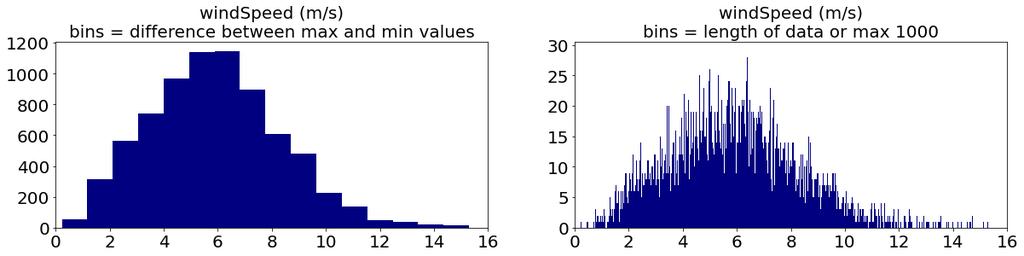

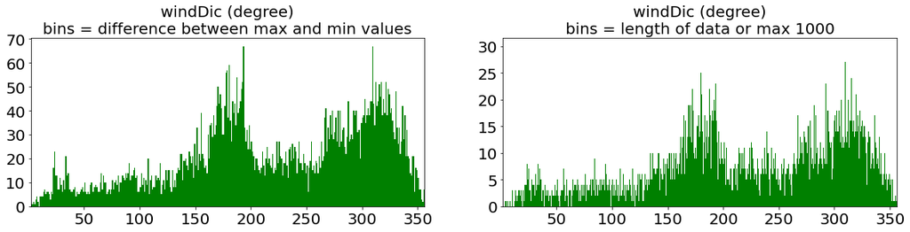

```
Cumulative histograms
```

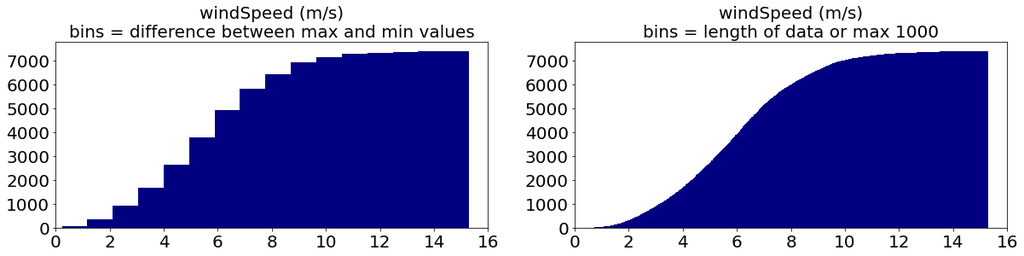

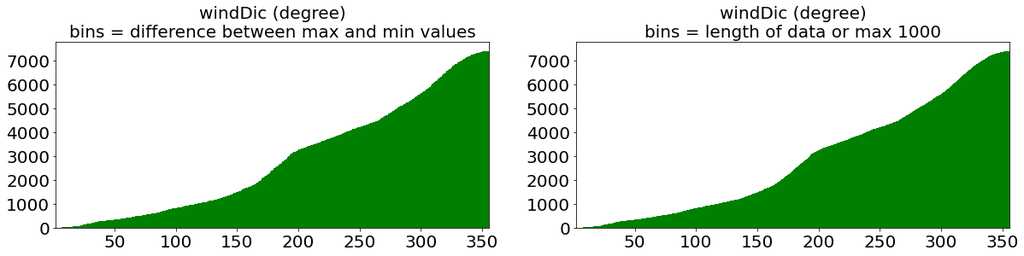

```python
for column, color in zip(columns_forecast,COLORS_FORECAST):
    title_1 = '{}\nbins = difference between max and min values'.format(column)
    title_2 = '{}\nbins = length of data or max 1000'.format(column)
    plot_histograms(dataset1_forecast[column], title_1, title_2, color)

print('\nCumulative histograms\n')
for column, color in zip(columns_forecast,COLORS_FORECAST):
    title_1 = '{}\nbins = difference between max and min values'.format(column)
    title_2 = '{}\nbins = length of data or max 1000'.format(column)
    plot_histograms_cumulative(dataset1_forecast[column], title_1, title_2, color)
```

### Dataset 2 forecast

```python
dataset2_forecast.describe()
```

|  | windSpeed (m/s) | windDic (degree) |
| --- | --- | --- |
| count | 769.000000 | 769.000000 |
| mean | 8.773314 | 259.772540 |
| std | 3.922052 | 68.259443 |
| min | 1.308578 | 13.547907 |
| 25% | 5.941081 | 236.545750 |
| 50% | 8.713832 | 286.432778 |
| 75% | 11.263311 | 309.198375 |
| max | 19.083787 | 353.798375 |

```python
print('The {} dataset contains {} row(s).'.format('dataset2_forecast', len(dataset2_forecast[column])))
for column in dataset2_forecast.columns:
    mask = pd.to_numeric(dataset2_forecast[column], errors='coerce').isna()
    print('\n{}'.format(column))
    print('   There are {} different value(s) in the column.'.format(dataset2_forecast[column].nunique()))
    print('   There are {} missing value(s) in the column.'.format(dataset2_forecast[column].isnull().sum()))
    print('   There are {} non-digit value(s) in the column.'.format(mask.sum()))
```

```
The dataset2_forecast dataset contains 769 row(s).

Time
   There are 769 different value(s) in the column.
   There are 0 missing value(s) in the column.
   There are 769 non-digit value(s) in the column.

windSpeed (m/s)
   There are 769 different value(s) in the column.
   There are 0 missing value(s) in the column.
   There are 0 non-digit value(s) in the column.

windDic (degree)
   There are 769 different value(s) in the column.
   There are 0 missing value(s) in the column.
   There are 0 non-digit value(s) in the column.
```

In the dataset2_forecast dataset each columns and values work as expected.

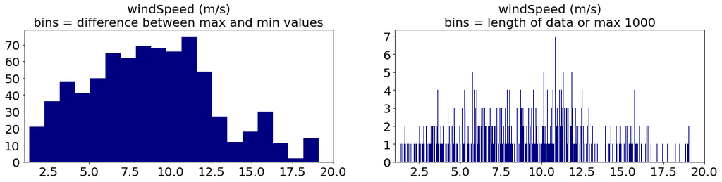

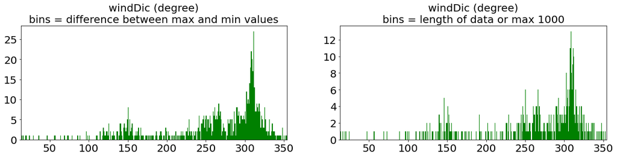

```
Cumulative histograms
```

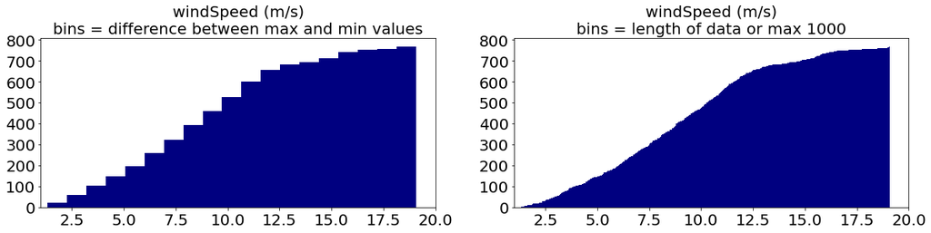

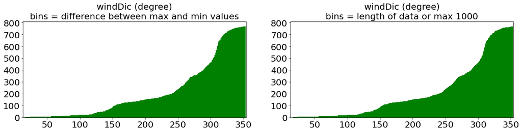

```python
for column, color in zip(columns_forecast, COLORS_FORECAST):
    title_1 = '{}\nbins = difference between max and min values'.format(column)
    title_2 = '{}\nbins = length of data or max 1000'.format(column)
    plot_histograms(dataset2_forecast[column], title_1, title_2, color)

print('\nCumulative histograms\n')
for column, color in zip(columns_forecast,COLORS_FORECAST):
    title_1 = '{}\nbins = difference between max and min values'.format(column)
    title_2 = '{}\nbins = length of data or max 1000'.format(column)
    plot_histograms_cumulative(dataset2_forecast[column], title_1, title_2, color)
```

### Dataset 3 forecast

```python
dataset3_forecast.describe()
```

|  | windSpeed (m/s) | windDic (degree) |
| --- | --- | --- |
| count | 2099.000000 | 2099.000000 |
| mean | 9.007293 | 205.664011 |
| std | 4.027943 | 96.486586 |
| min | 0.322699 | 2.785147 |
| 25% | 6.006268 | 137.164529 |
| 50% | 8.580431 | 218.650538 |
| 75% | 11.614790 | 289.229115 |
| max | 20.788200 | 357.463000 |

```python
print('The {} dataset contains {} row(s).'.format('dataset3_forecast', len(dataset3_forecast[column])))
for column in dataset3_forecast.columns:
    mask = pd.to_numeric(dataset3_forecast[column], errors='coerce').isna()
    print('\n{}'.format(column))
    print('   There are {} different value(s) in the column.'.format(dataset3_forecast[column].nunique()))
    print('   There are {} missing value(s) in the column.'.format(dataset3_forecast[column].isnull().sum()))
    print('   There are {} non-digit value(s) in the column.'.format(mask.sum()))
```

```
The dataset3_forecast dataset contains 2099 row(s).

Time
   There are 2099 different value(s) in the column.
   There are 0 missing value(s) in the column.
   There are 2099 non-digit value(s) in the column.

windSpeed (m/s)
   There are 2099 different value(s) in the column.
   There are 0 missing value(s) in the column.
   There are 0 non-digit value(s) in the column.

windDic (degree)
   There are 2098 different value(s) in the column.
   There are 0 missing value(s) in the column.
   There are 0 non-digit value(s) in the column.
```

In the dataset3_forecast dataset each columns and values work as expected.

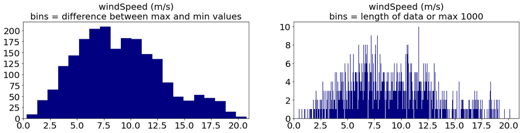

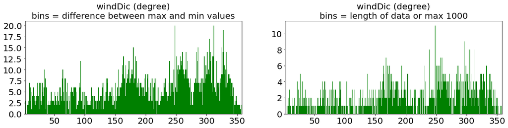

```
Cumulative histograms
```

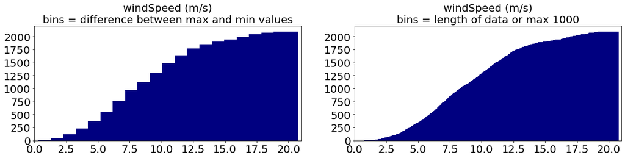

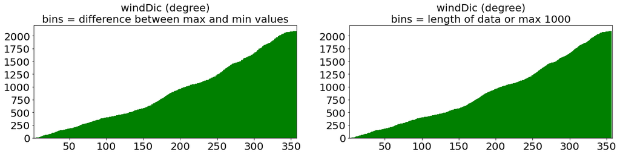

```python
for column, color in zip(columns_forecast, COLORS_FORECAST):
    title_1 = '{}\nbins = difference between max and min values'.format(column)
    title_2 = '{}\nbins = length of data or max 1000'.format(column)
    plot_histograms(dataset3_forecast[column], title_1, title_2, color)

print('\nCumulative histograms\n')
for column, color in zip(columns_forecast,COLORS_FORECAST):
    title_1 = '{}\nbins = difference between max and min values'.format(column)
    title_2 = '{}\nbins = length of data or max 1000'.format(column)
    plot_histograms_cumulative(dataset3_forecast[column], title_1, title_2, color)
```

### Dataset 1 measurement

```python
dataset1_measurement.describe()
```

|  | timeStamp | availableMW | windSpeed | windPower |
| --- | --- | --- | --- | --- |
| count | 88941 | 88941 | 88941 | 88941 |
| unique | 88941 | 422 | 185 | 223 |
| top | 2018-04-13 10:00 | 42 | 6 | 0 |
| freq | 1 | 21458 | 2096 | 7799 |

There are missing content in the output of describe(). This confirms the earlier suspision, the dataset contains invalid records.

```python
print('The {} dataset contains {} row(s).'.format('dataset1_measurement', len(dataset1_measurement)))
for column in dataset1_measurement.columns:
    mask = pd.to_numeric(dataset1_measurement[column], errors='coerce').isna()
    print('\n{}'.format(column))
    print('   There are {} different value(s) in the column.'.format(dataset1_measurement[column].nunique()))
    print('   There are {} missing value(s) in the column.'.format(dataset1_measurement[column].isnull().sum()))
    print('   There are {} non-digit value(s) in the column.'.format(mask.sum()))

    # Fill the 'columns_measurement' variable
    if column != 'timeStamp':
        columns_measurement.append(column)
```

```
The dataset1_measurement dataset contains 88941 row(s).

timeStamp
   There are 88941 different value(s) in the column.
   There are 0 missing value(s) in the column.
   There are 88941 non-digit value(s) in the column.

availableMW
   There are 422 different value(s) in the column.
   There are 0 missing value(s) in the column.
   There are 905 non-digit value(s) in the column.

windSpeed
   There are 185 different value(s) in the column.
   There are 0 missing value(s) in the column.
   There are 856 non-digit value(s) in the column.

windPower
   There are 223 different value(s) in the column.
   There are 0 missing value(s) in the column.
   There are 856 non-digit value(s) in the column.
```

There are non-digit values in the digit column. This is the cause of errors. To prevent failures, those records has to be removed.

#### Cleaning the dataset: removing non-digits values

```python
dataset1_measurement_clean = dataset1_measurement.copy(deep=True)
for column in columns_measurement:
    dataset1_measurement_clean[column] = pd.to_numeric(dataset1_measurement_clean[column], errors='coerce')

dataset1_measurement_clean = dataset1_measurement_clean.dropna()
dataset1_measurement_clean.sample(3)
```

|  | timeStamp | availableMW | windSpeed | windPower |
| --- | --- | --- | --- | --- |
| 2451 | 2018-01-09 12:15 | 36.0 | 7.6 | 16.03830 |
| 40775 | 2018-05-23 10:00 | 39.0 | 5.4 | 4.88318 |
| 583 | 2018-01-03 0:35 | 37.5 | 8.1 | 19.75120 |

```python
dataset1_measurement_clean.describe()
```

|  | availableMW | windSpeed | windPower |
| --- | --- | --- | --- |
| count | 88035.000000 | 88035.000000 | 88035.000000 |
| mean | 35.271537 | 7.339864 | 16.619034 |
| std | 10.651027 | 2.911394 | 14.022428 |
| min | 0.000000 | 0.000000 | 0.000000 |
| 25% | 35.200000 | 5.300000 | 4.548010 |
| 50% | 39.000000 | 7.100000 | 12.703600 |
| 75% | 41.000000 | 9.300000 | 28.767400 |
| max | 42.000000 | 18.900000 | 45.000000 |

```python
print('The {} dataset contains {} row(s).'.format('dataset1_measurement_clean', len(dataset1_measurement_clean)))
for column in dataset1_measurement_clean.columns:
    mask = pd.to_numeric(dataset1_measurement_clean[column], errors='coerce').isna()
    print('\n{}'.format(column))
    print('   There are {} different value(s) in the column.'.format(dataset1_measurement_clean[column].nunique()))
    print('   There are {} missing value(s) in the column.'.format(dataset1_measurement_clean[column].isnull().sum()))
    print('   There are {} non-digit value(s) in the column.'.format(mask.sum()))

    # Fill the 'columns_measurement' variable
    if column != 'timeStamp':
        columns_measurement.append(column)
```

```
The dataset1_measurement_clean dataset contains 88035 row(s).

timeStamp
   There are 88035 different value(s) in the column.
   There are 0 missing value(s) in the column.
   There are 88035 non-digit value(s) in the column.

availableMW
   There are 421 different value(s) in the column.
   There are 0 missing value(s) in the column.
   There are 0 non-digit value(s) in the column.

windSpeed
   There are 184 different value(s) in the column.
   There are 0 missing value(s) in the column.
   There are 0 non-digit value(s) in the column.

windPower
   There are 222 different value(s) in the column.
   There are 0 missing value(s) in the column.
   There are 0 non-digit value(s) in the column.
```

Now in the dataset1_measurement dataset each columns and values work as expected.

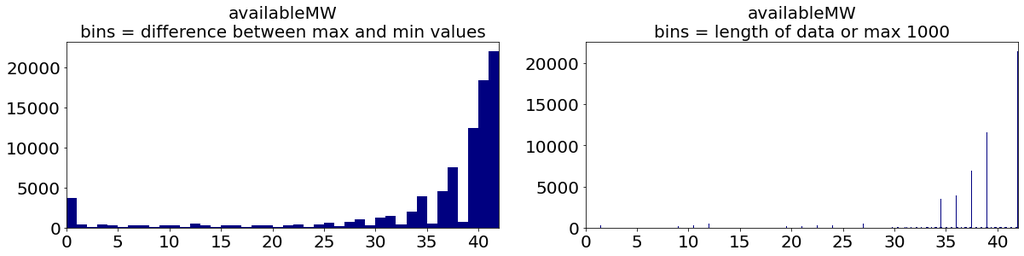

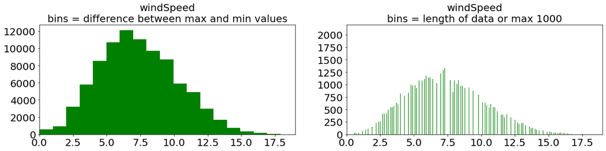

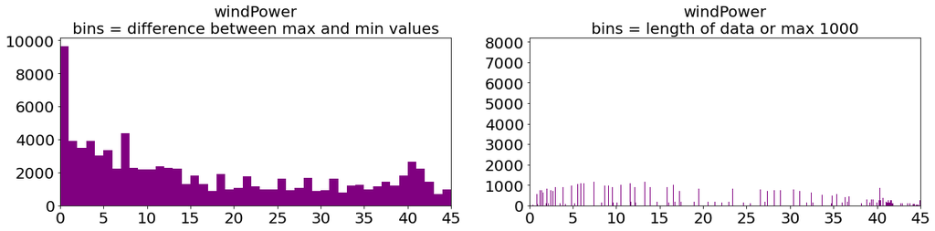

```
Cumulative histograms
```

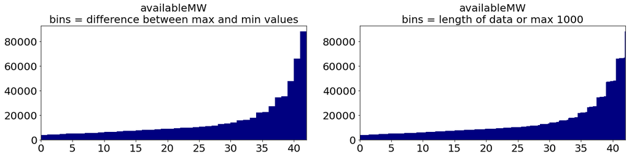

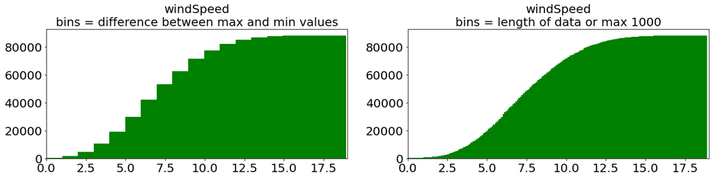

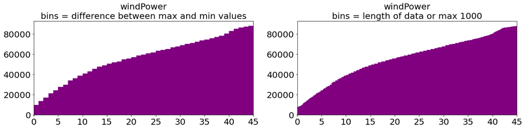

```python
for column, color in zip(columns_measurement,COLORS_MEASUREMENT):
    title_1 = '{}\nbins = difference between max and min values'.format(column)
    title_2 = '{}\nbins = length of data or max 1000'.format(column)
    plot_histograms(dataset1_measurement_clean[column], title_1, title_2, color)

print('\nCumulative histograms\n')
for column, color in zip(columns_measurement,COLORS_MEASUREMENT):
    title_1 = '{}\nbins = difference between max and min values'.format(column)
    title_2 = '{}\nbins = length of data or max 1000'.format(column)
    plot_histograms_cumulative(dataset1_measurement_clean[column], title_1, title_2, color)
```

### Dataset 2 measurement

```python
dataset2_measurement.describe()
```

|  | timeStamp | availableMW | windSpeed | windPower |
| --- | --- | --- | --- | --- |
| count | 8641 | 8641 | 8641 | 8641 |
| unique | 8641 | 55 | 187 | 113 |
| top | 2018-12-02 3:25 | 99 | 4.6 | 0 |
| freq | 1 | 5748 | 146 | 704 |

The situation is similar as it was with the dataset1_measurement.

```python
print('The {} dataset contains {} row(s).'.format('dataset1_measurement', len(dataset2_measurement)))
for column in dataset2_measurement.columns:
    mask = pd.to_numeric(dataset2_measurement[column], errors='coerce').isna()
    print('\n{}'.format(column))
    print('   There are {} different value(s) in the column.'.format(dataset2_measurement[column].nunique()))
    print('   There are {} missing value(s) in the column.'.format(dataset2_measurement[column].isnull().sum()))
    print('   There are {} non-digit value(s) in the column.'.format(mask.sum()))
```

```
The dataset1_measurement dataset contains 8641 row(s).

timeStamp
   There are 8641 different value(s) in the column.
   There are 0 missing value(s) in the column.
   There are 8641 non-digit value(s) in the column.

availableMW
   There are 55 different value(s) in the column.
   There are 0 missing value(s) in the column.
   There are 3 non-digit value(s) in the column.

windSpeed
   There are 187 different value(s) in the column.
   There are 0 missing value(s) in the column.
   There are 7 non-digit value(s) in the column.

windPower
   There are 113 different value(s) in the column.
   There are 0 missing value(s) in the column.
   There are 7 non-digit value(s) in the column.
```

```python
dataset2_measurement_clean = dataset2_measurement.copy(deep=True)
for column in columns_measurement:
    dataset2_measurement_clean[column] = pd.to_numeric(dataset2_measurement_clean[column], errors='coerce')

dataset2_measurement_clean = dataset2_measurement_clean.dropna()
dataset2_measurement_clean.sample(3)
```

|  | timeStamp | availableMW | windSpeed | windPower |
| --- | --- | --- | --- | --- |
| 4441 | 2018-12-16 10:05 | 99.0 | 4.7 | 4.75351 |
| 3024 | 2018-12-11 12:00 | 97.2 | 5.0 | 7.48540 |
| 1725 | 2018-12-06 23:45 | 0.0 | 0.0 | 0.00000 |

```python
dataset2_measurement_clean.describe()
```

|  | availableMW | windSpeed | windPower |
| --- | --- | --- | --- |
| count | 8634.000000 | 8634.000000 | 8634.000000 |
| mean | 96.992784 | 8.942831 | 50.012416 |
| std | 8.992739 | 3.885827 | 35.147272 |
| min | 0.000000 | 0.000000 | 0.000000 |
| 25% | 97.200000 | 5.700000 | 13.967300 |
| 50% | 99.000000 | 8.900000 | 53.016500 |
| 75% | 99.000000 | 11.700000 | 84.319700 |
| max | 99.000000 | 19.400000 | 99.000000 |

```python
print('The {} dataset contains {} row(s).'.format('dataset2_measurement_clean', len(dataset2_measurement_clean)))
for column in dataset2_measurement_clean.columns:
    mask = pd.to_numeric(dataset2_measurement_clean[column], errors='coerce').isna()
    print('\n{}'.format(column))
    print('   There are {} different value(s) in the column.'.format(dataset2_measurement_clean[column].nunique()))
    print('   There are {} missing value(s) in the column.'.format(dataset2_measurement_clean[column].isnull().sum()))
    print('   There are {} non-digit value(s) in the column.'.format(mask.sum()))
```

```
The dataset2_measurement_clean dataset contains 8634 row(s).

timeStamp
   There are 8634 different value(s) in the column.
   There are 0 missing value(s) in the column.
   There are 8634 non-digit value(s) in the column.

availableMW
   There are 54 different value(s) in the column.
   There are 0 missing value(s) in the column.
   There are 0 non-digit value(s) in the column.

windSpeed
   There are 186 different value(s) in the column.
   There are 0 missing value(s) in the column.
   There are 0 non-digit value(s) in the column.

windPower
   There are 112 different value(s) in the column.
   There are 0 missing value(s) in the column.
   There are 0 non-digit value(s) in the column.
```

Now in the dataset2_measurement dataset each columns and values work as expected.

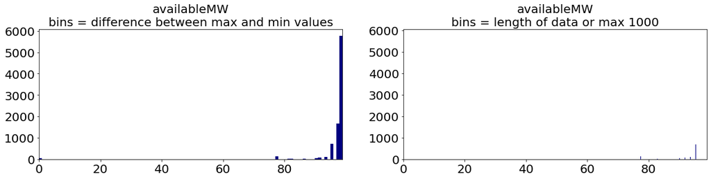

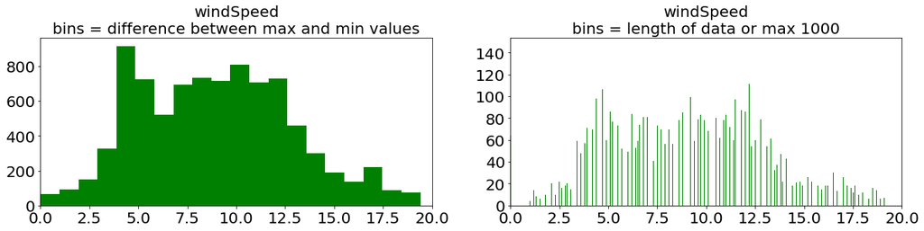

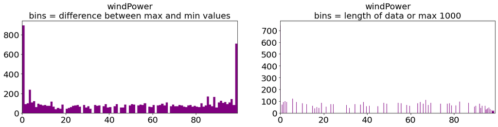

```
Cumulative histograms
```

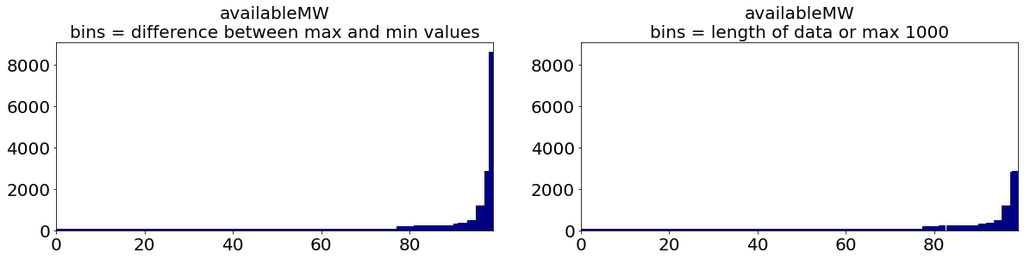

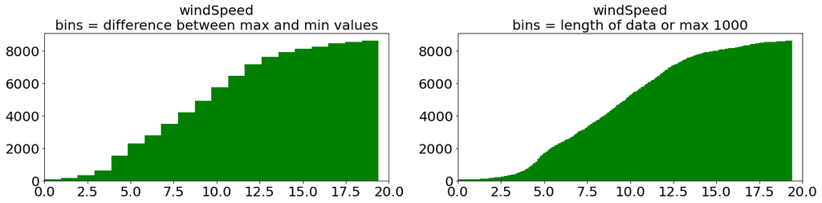

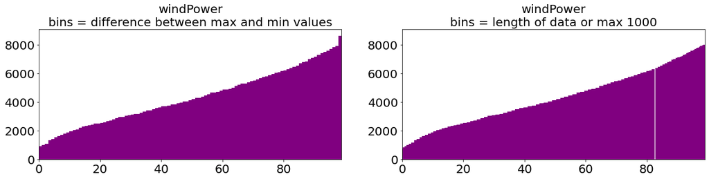

```python
for column, color in zip(columns_measurement,COLORS_MEASUREMENT):
    title_1 = '{}\nbins = difference between max and min values'.format(column)
    title_2 = '{}\nbins = length of data or max 1000'.format(column)
    plot_histograms(dataset2_measurement_clean[column], title_1, title_2, color)

print('\nCumulative histograms\n')
for column, color in zip(columns_measurement,COLORS_MEASUREMENT):
    title_1 = '{}\nbins = difference between max and min values'.format(column)
    title_2 = '{}\nbins = length of data or max 1000'.format(column)
    plot_histograms_cumulative(dataset2_measurement_clean[column], title_1, title_2, color)
```

### Cleaning both measurement datasets from invalid entries

There are entries that contains data that slow the learning process and decrease the convergence.

- Since AvailableMW means the maximum capacity at the moment, every records are meaningless where AvailableMW = 0

```python
# removing record where AvailableMW = 0

print('Dataset 1:')
actual_remove = len(dataset1_measurement_clean[dataset1_measurement_clean['availableMW'] == 0])
removed_records_1 += actual_remove
print('{} record(s) removed.'.format(actual_remove))
dataset1_measurement_clean = dataset1_measurement_clean[dataset1_measurement_clean['availableMW'] != 0]
print('New length of dataset is {} record(s).'.format(len(dataset1_measurement_clean)))

print('\nDataset 2:')
actual_remove = len(dataset2_measurement_clean[dataset2_measurement_clean['availableMW'] == 0])
removed_records_2 += actual_remove
print('{} record(s) removed.'.format(actual_remove))
dataset2_measurement_clean = dataset2_measurement_clean[dataset2_measurement_clean['availableMW'] != 0]
print('New length of dataset is {} record(s).'.format(len(dataset2_measurement_clean)))
```

```
Dataset 1:
3543 record(s) removed.
New length of dataset is 84492 record(s).

Dataset 2:
64 record(s) removed.
New length of dataset is 8570 record(s).
```

```python
# creating ratio column: ratio = windPower / availableMW
dataset1_measurement_clean['ratio'] = dataset1_measurement_clean['windPower'] / dataset1_measurement_clean['availableMW']
dataset2_measurement_clean['ratio'] = dataset2_measurement_clean['windPower'] / dataset2_measurement_clean['availableMW']
```

```python
helper = 0
print('Dataset 1')
print('Different thresholds on windspeed whare ratio > 1.0')
print('Sum means how many records are involved\n')
print('{}\t{}\t{}'.format('thd', 'diff', 'sum'))
for i in range(0, 200, 5):
    value = len(dataset1_measurement_clean[(dataset1_measurement_clean['ratio'] > 1.0) & (dataset1_measurement_clean['windSpeed'] < (i/10))])
    helper = value
    difference = helper - value
    helper = value
    print('{:>3.1f}\t{:4d}\t{:4d}'.format(i/10, difference, value))

helper = 0
print('\n\nDataset 2')
print('Different thresholds on windspeed whare ratio > 1.0')
print('Sum means how many records are involved\n')
print('{}\t{}\t{}'.format('thd', 'diff', 'sum'))
for i in range(0, 200, 5):
    value = len(dataset2_measurement_clean[(dataset2_measurement_clean['ratio'] > 1.0) & (dataset2_measurement_clean['windSpeed'] < (i/10))])
    difference = helper - value
    helper = value
    print('{:>3.1f}\t{:4d}\t{:4d}'.format(i/10, difference, value))
```

```
Dataset 1
Different thresholds on windspeed whare ratio > 1.0
Sum means how many records are involved

thd	diff	sum
0.0	   0	   0
0.5	   0	   0
1.0	   0	   0
1.5	   0	   0
2.0	   0	   0
2.5	   0	   0
3.0	   0	   0
3.5	   0	   0
4.0	   0	  11
4.5	   0	  16
5.0	   0	  24
5.5	   0	  30
6.0	   0	  48
6.5	   0	  62
7.0	   0	  78
7.5	   0	 101
8.0	   0	 125
8.5	   0	 151
9.0	   0	 163
9.5	   0	 175
10.0	   0	 233
10.5	   0	 467
11.0	   0	 948
11.5	   0	2410
12.0	   0	3090
12.5	   0	4007
13.0	   0	4863
13.5	   0	5432
14.0	   0	5916
14.5	   0	6236
15.0	   0	6461
15.5	   0	6646
16.0	   0	6771
16.5	   0	6864
17.0	   0	6911
```

[output cut: 37 more lines]

```
12.5	   0	   0
13.0	   0	   0
13.5	   0	   0
14.0	  -9	   9
14.5	 -20	  29
15.0	 -33	  62
15.5	 -24	  86
16.0	 -21	 107
16.5	 -16	 123
17.0	 -12	 135
17.5	 -21	 156
18.0	 -17	 173
18.5	  -2	 175
19.0	  -4	 179
19.5	  -2	 181
```

```python
# removing record where ratio > 1.0 and windspeed is slower than 12 m/s

print('Dataset 1:')
actual_remove = len(dataset1_measurement_clean[(dataset1_measurement_clean['ratio'] > 1.0) & (dataset1_measurement_clean['windSpeed'] < 12)])
removed_records_1 += actual_remove
print('{} record(s) removed.'.format(actual_remove))
indexnames = dataset1_measurement_clean[(dataset1_measurement_clean['ratio'] > 1.0) & (dataset1_measurement_clean['windSpeed'] < 12)].index
dataset1_measurement_clean.drop(indexnames, inplace = True)
print('New length of dataset is {} record(s).'.format(len(dataset1_measurement_clean)))

print('\nDataset 2:')
actual_remove = len(dataset2_measurement_clean[(dataset2_measurement_clean['ratio'] > 1.0) & (dataset2_measurement_clean['windSpeed'] < 12)])
removed_records_2 += actual_remove
print('{} record(s) removed.'.format(actual_remove))
indexnames = dataset2_measurement_clean[(dataset2_measurement_clean['ratio'] > 1.0) & (dataset2_measurement_clean['windSpeed'] < 12)].index
dataset2_measurement_clean.drop(indexnames, inplace = True)
print('New length of dataset is {} record(s).'.format(len(dataset2_measurement_clean)))
```

```
Dataset 1:
3090 record(s) removed.
New length of dataset is 81402 record(s).

Dataset 2:
0 record(s) removed.
New length of dataset is 8570 record(s).
```

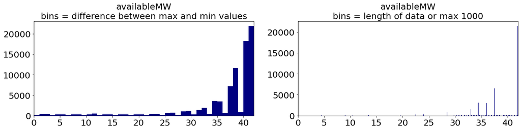

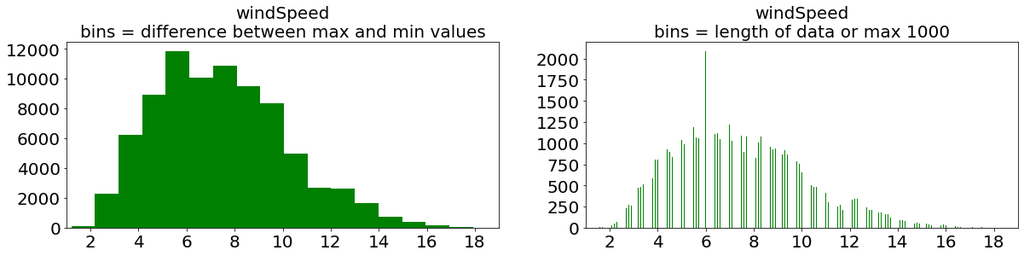

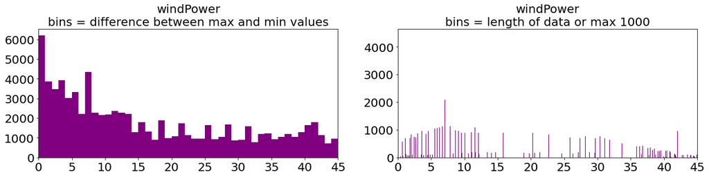

```
Cumulative histograms
```

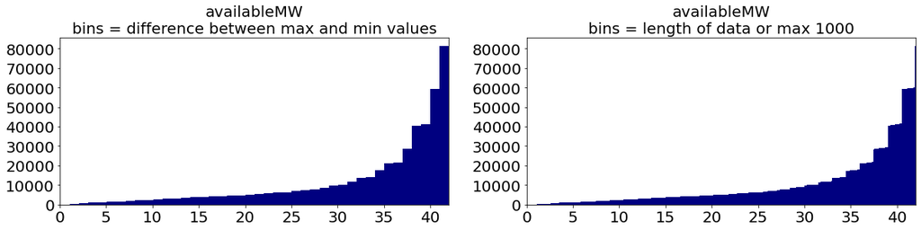

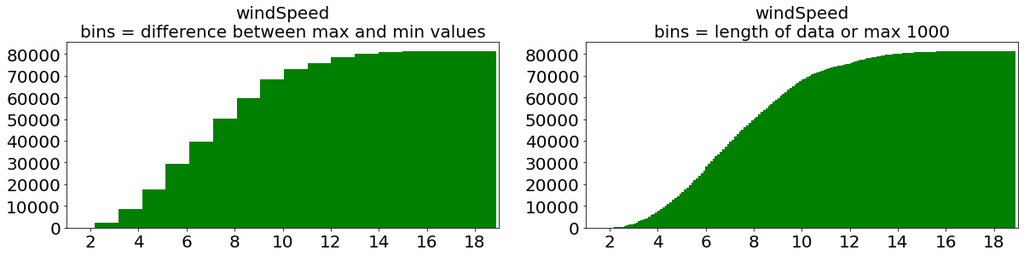

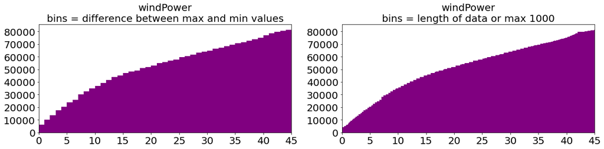

```python
columns_measurement_clean = columns_measurement
columns_measurement_clean.append('ratio')

for column, color in zip(columns_measurement_clean,COLORS_MEASUREMENT):
    title_1 = '{}\nbins = difference between max and min values'.format(column)
    title_2 = '{}\nbins = length of data or max 1000'.format(column)
    plot_histograms(dataset1_measurement_clean[column], title_1, title_2, color)

print('\nCumulative histograms\n')
for column, color in zip(columns_measurement,COLORS_MEASUREMENT):
    title_1 = '{}\nbins = difference between max and min values'.format(column)
    title_2 = '{}\nbins = length of data or max 1000'.format(column)
    plot_histograms_cumulative(dataset1_measurement_clean[column], title_1, title_2, color)
```

```
Dataset 2:
```

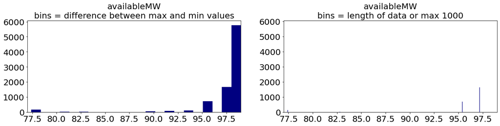

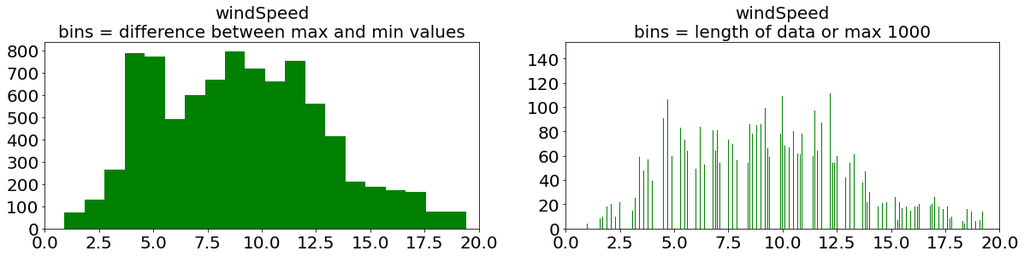

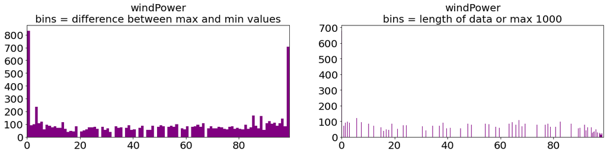

```
Cumulative histograms
```

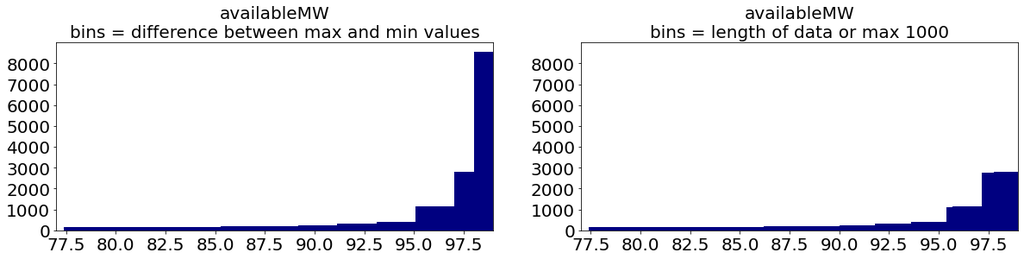

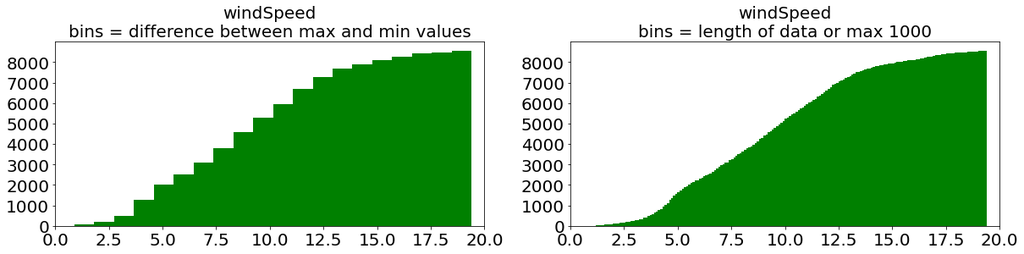

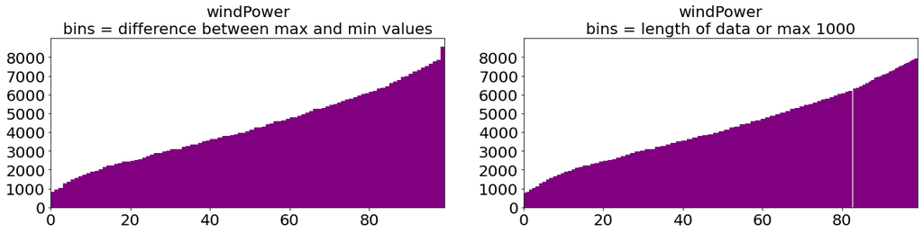

```python
print('\n\n\nDataset 2:')
for column, color in zip(columns_measurement,COLORS_MEASUREMENT):
    title_1 = '{}\nbins = difference between max and min values'.format(column)
    title_2 = '{}\nbins = length of data or max 1000'.format(column)
    plot_histograms(dataset2_measurement_clean[column], title_1, title_2, color)

print('\nCumulative histograms\n')
for column, color in zip(columns_measurement,COLORS_MEASUREMENT):
    title_1 = '{}\nbins = difference between max and min values'.format(column)
    title_2 = '{}\nbins = length of data or max 1000'.format(column)
    plot_histograms_cumulative(dataset2_measurement_clean[column], title_1, title_2, color)
```

# Summary

Forecast datasets contains the records in a right way compared with the measurement datasets. The last ones contains invalid non-numeric and incomprehensible records. There are a lof of records where values in **availableMW** are lower than values in **windPower**.